# HW3 Solutions

Rushal Sohal; github: rsohal

2/18/2020

```r
data(tips, package = "reshape2")
```

Q1.

```r
numParty <- nrow(tips)
numParty
```

```
## [1] 244
```

The waiter served 244 parties.

Q2.

```r
str(tips)
```

```
## 'data.frame':    244 obs. of  7 variables:
##  $ total_bill: num  17 10.3 21 23.7 24.6 ...
##  $ tip       : num  1.01 1.66 3.5 3.31 3.61 4.71 2 3.12 1.96 3.23 ...
##  $ sex       : Factor w/ 2 levels "Female","Male": 1 2 2 2 1 2 2 2 2 2 ...
##  $ smoker    : Factor w/ 2 levels "No","Yes": 1 1 1 1 1 1 1 1 1 1 ...
##  $ day       : Factor w/ 4 levels "Fri","Sat","Sun",..: 3 3 3 3 3 3 3 3 3 3 ...
##  $ time      : Factor w/ 2 levels "Dinner","Lunch": 1 1 1 1 1 1 1 1 1 1 ...
##  $ size      : int  2 3 3 2 4 4 2 4 2 2 ...
```

total_bill and tip are Numeric (double here), size is an Integer, and everything else is of type Factor.

Q3.

```r
day <- tips$day
day <- day[order(match(day,  c("Thur","Fri","Sat","Sun")))]
day
```

```
##   [1] Thur Thur Thur Thur Thur Thur Thur Thur Thur Thur Thur Thur Thur Thur Thur
##  [16] Thur Thur Thur Thur Thur Thur Thur Thur Thur Thur Thur Thur Thur Thur Thur
##  [31] Thur Thur Thur Thur Thur Thur Thur Thur Thur Thur Thur Thur Thur Thur Thur
##  [46] Thur Thur Thur Thur Thur Thur Thur Thur Thur Thur Thur Thur Thur Thur Thur
##  [61] Thur Thur Fri  Fri  Fri  Fri  Fri  Fri  Fri  Fri  Fri  Fri  Fri  Fri  Fri
##  [76] Fri  Fri  Fri  Fri  Fri  Fri  Sat  Sat  Sat  Sat  Sat  Sat  Sat  Sat  Sat
##  [91] Sat  Sat  Sat  Sat  Sat  Sat  Sat  Sat  Sat  Sat  Sat  Sat  Sat  Sat  Sat
## [106] Sat  Sat  Sat  Sat  Sat  Sat  Sat  Sat  Sat  Sat  Sat  Sat  Sat  Sat  Sat
## [121] Sat  Sat  Sat  Sat  Sat  Sat  Sat  Sat  Sat  Sat  Sat  Sat  Sat  Sat  Sat
## [136] Sat  Sat  Sat  Sat  Sat  Sat  Sat  Sat  Sat  Sat  Sat  Sat  Sat  Sat  Sat
## [151] Sat  Sat  Sat  Sat  Sat  Sat  Sat  Sat  Sat  Sat  Sat  Sat  Sat  Sat  Sat
## [166] Sat  Sat  Sat  Sun  Sun  Sun  Sun  Sun  Sun  Sun  Sun  Sun  Sun  Sun  Sun
## [181] Sun  Sun  Sun  Sun  Sun  Sun  Sun  Sun  Sun  Sun  Sun  Sun  Sun  Sun  Sun
## [196] Sun  Sun  Sun  Sun  Sun  Sun  Sun  Sun  Sun  Sun  Sun  Sun  Sun  Sun  Sun
## [211] Sun  Sun  Sun  Sun  Sun  Sun  Sun  Sun  Sun  Sun  Sun  Sun  Sun  Sun  Sun
## [226] Sun  Sun  Sun  Sun  Sun  Sun  Sun  Sun  Sun  Sun  Sun  Sun  Sun  Sun  Sun
## [241] Sun  Sun  Sun  Sun
## Levels: Fri Sat Sun Thur
```

Q4.

```r
female5 <- tips[(tips[,7] >= 5) & (tips[,3] == "Female"), ]
female5
```

```
##     total_bill  tip    sex smoker  day   time size
## 126      29.80 4.20 Female     No Thur  Lunch    6
## 144      27.05 5.00 Female     No Thur  Lunch    6
## 156      29.85 5.14 Female     No  Sun Dinner    5
```

Q5.

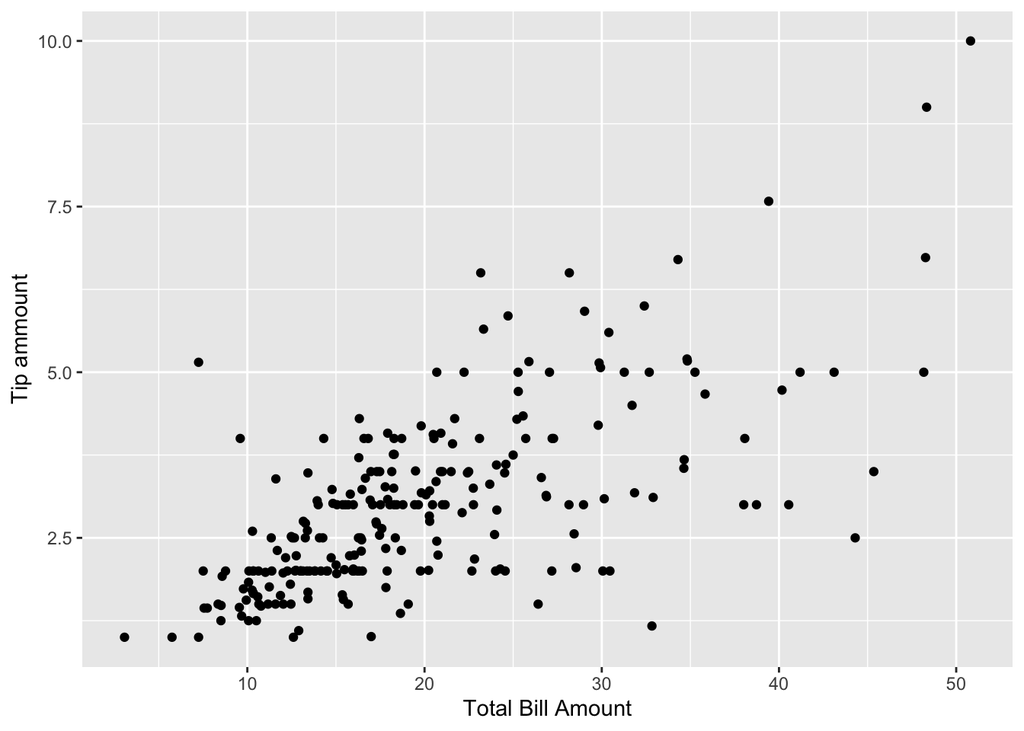

```r
library(ggplot2)
ggplot(tips, aes(x=total_bill, y=tip)) + geom_point() + xlab("Total Bill Amount") + ylab("Tip ammount")
```

total_bill and tip have a strong positive correlation. As total_bill increases the tip amount increases and vice-versa.

Q6.

1. There were outliers for some lower amounts of total_bill. For instance, there’s a tip of $5+ for a bill of 7-8 USD.
2. As total_bill increases the relationship is less linear and results in a weak correlation (mostly after $20-25 bill amount).

Q7.

```r
tips$tiprate <-  tips$tip/tips$total_bill
mean (tips$tiprate)
```

```
## [1] 0.1608026
```

On average, a waiter is tipped 16% of the total bill.

Q8.

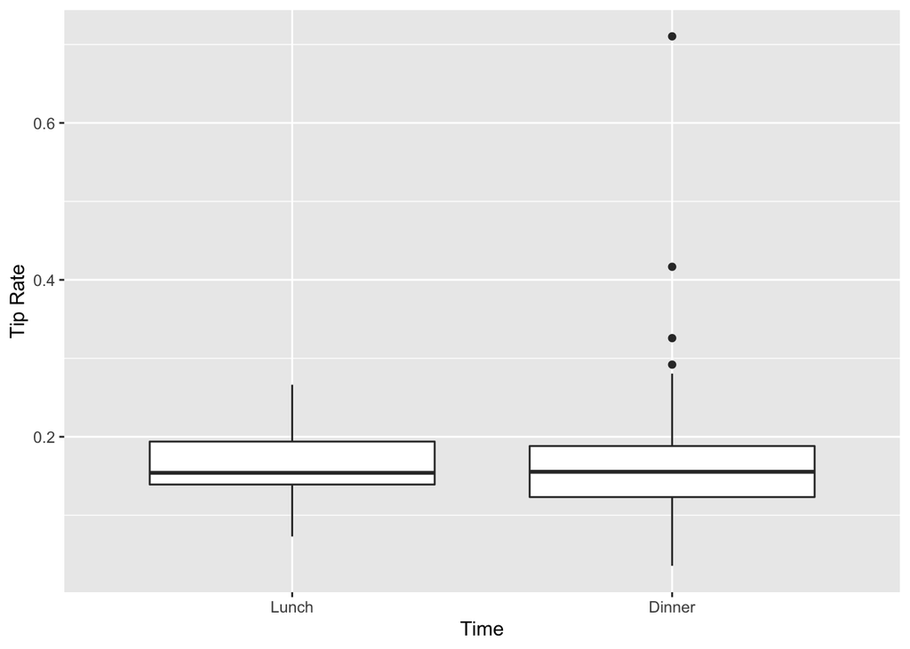

```r
ggplot(tips,aes(x= factor(tips$time,levels =c("Lunch","Dinner")), y =tiprate))+geom_boxplot()+
xlab("Time")+
ylab("Tip Rate")
```

The average tiprate is about the same, however, Lunch has a larger/wider upper quartile range. Besides, there are some outliers in Dinner.

Q9.

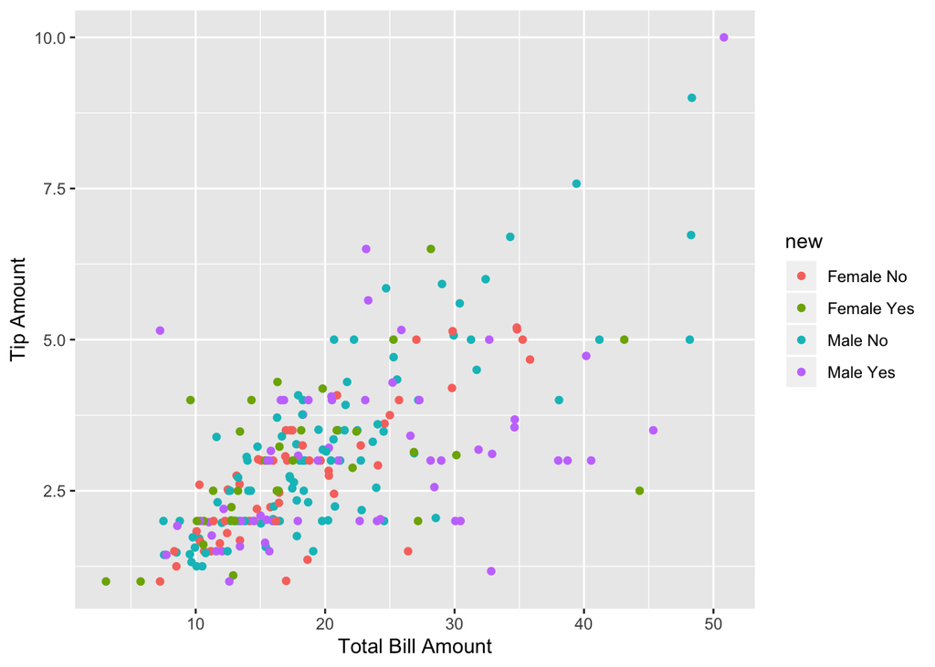

```r
tmp <-tips
tmp$new <- paste(tips$sex,tips$smoker)
#made a new column by making a temporary dataset
ggplot(tmp,aes(x =total_bill,y=tip,color = new)) +geom_point()+
xlab("Total Bill Amount")+
ylab("Tip Amount")
```

Non-smokers tend to tip higher for both genders. Males usually have a higher total bill amount.

Q10.

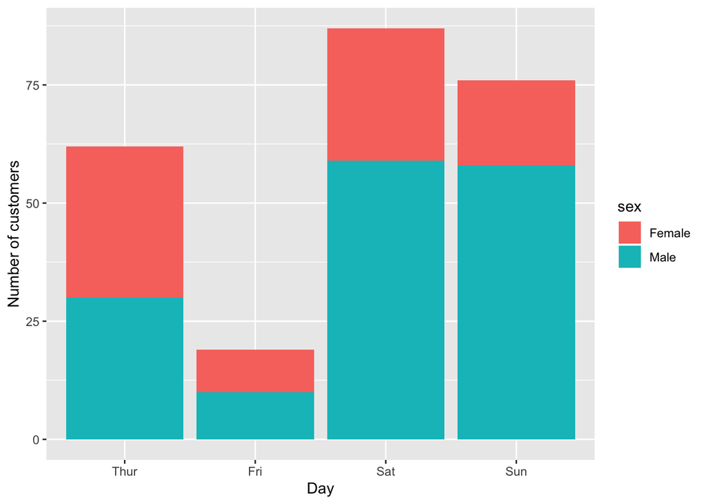

```r
ggplot(tips,aes(x=factor(day,levels = c("Thur","Fri","Sat","Sun")),fill=sex))+geom_bar()+
xlab("Day")+
ylab("Number of customers")
```

For weekdays, it’s about equal, however, for weekends, more men tend to go to the restaurant.